# lab-01_unido_V2

2026-02-06

## Carga y preparación de datos

## 1 Resumen general del dataset

```
##        id              budget             genres            homePage
##  Min.   :      5   Min.   :        0   Length:19883       Length:19883
##  1st Qu.: 146220   1st Qu.:        0   Class :character   Class :character
##  Median : 869623   Median :        0   Mode  :character   Mode  :character
##  Mean   : 902240   Mean   :  9413280
##  3rd Qu.:1589602   3rd Qu.:  1000000
##  Max.   :1627166   Max.   :380000000
##
##  productionCompany  productionCompanyCountry productionCountry
##  Length:19883       Length:19883             Length:19883
##  Class :character   Class :character         Class :character
##  Mode  :character   Mode  :character         Mode  :character
##
##
##
##
##     revenue             runtime         video           director
##  Min.   :0.000e+00   Min.   :  0.00   Mode :logical   Length:19883
##  1st Qu.:0.000e+00   1st Qu.: 10.00   FALSE:19313     Class :character
##  Median :0.000e+00   Median : 86.00   TRUE :84        Mode  :character
##  Mean   :2.879e+07   Mean   : 66.09   NA's :486
##  3rd Qu.:3.306e+05   3rd Qu.:103.00
##  Max.   :2.847e+09   Max.   :750.00
##
##     actors          actorsPopularity   actorsCharacter    originalTitle
##  Length:19883       Length:19883       Length:19883       Length:19883
##  Class :character   Class :character   Class :character   Class :character
##  Mode  :character   Mode  :character   Mode  :character   Mode  :character
##
##
##
##
##     title           originalLanguage     popularity        releaseDate
##  Length:19883       Length:19883       Min.   :0.000e+00   Length:19883
##  Class :character   Class :character   1st Qu.:5.460e-02   Class :character
##  Mode  :character   Mode  :character   Median :8.502e+00   Mode  :character
##                                        Mean   :2.625e+01
##                                        3rd Qu.:2.224e+01
##                                        Max.   :1.147e+04
##
```

[output cut: 9 more lines]

```
##  Min.   :  0.00            Min.   :     0   Min.   :     0   Min.   :     0
##  1st Qu.:  1.00            1st Qu.:     3   1st Qu.:     0   1st Qu.:     0
##  Median :  1.00            Median :     9   Median :     2   Median :     3
##  Mean   :  1.23            Mean   :  1082   Mean   :  3517   Mean   :  8224
##  3rd Qu.:  1.00            3rd Qu.:    21   3rd Qu.:     6   3rd Qu.:    12
##  Max.   :155.00            Max.   :919590   Max.   :922162   Max.   :922017
##                                             NA's   :37       NA's   :162
##   releaseYear
##  Min.   :1902
##  1st Qu.:2013
##  Median :2021
##  Mean   :2017
##  3rd Qu.:2025
##  Max.   :2026
##  NA's   :2
```

**Análisis:** El resumen permite ver la distribución básica de cada variable, sus rangos y si existen valores faltantes. Esto ayuda a detectar rápidamente columnas con muchos `NA` o escalas muy distintas entre variables. Con esta vista inicial se decide qué variables requieren limpieza o transformación antes de analizar. También sirve para ubicar posibles outliers por valores máximos inusuales.

## 2 Tipo de variable por columna

| variable | tipo | descripcion |
| --- | --- | --- |
| id | Cualitativa nominal | Identificador; numérico pero no mide magnitud |
| popularity | Cuantitativa continua | Índice (escala continua) |
| budget | Cuantitativa continua | Presupuesto (moneda) |
| revenue | Cuantitativa continua | Ingresos (moneda) |
| originalTitle/originaltitle | Cualitativa nominal | Texto |
| originalLanguage/originallanguage | Cualitativa nominal | Código de idioma |
| title | Cualitativa nominal | Texto |
| homePage/homepage | Cualitativa nominal | URL (alta cardinalidad, muchos NA) |
| video | Cualitativa nominal | Binaria (sí/no) |
| director | Cualitativa nominal | Nombre (alta cardinalidad) |
| runtime | Cuantitativa continua | Duración (minutos) |
| genres | Cualitativa nominal | Multi-etiqueta |
| genresAmount/genresamount | Cuantitativa discreta | Conteo de géneros |
| productionCompany/productioncompany | Cualitativa nominal | Texto / multi-etiqueta |
| productionCoAmount/productioncoamount | Cuantitativa discreta | Conteo de compañías |
| productionCountry/productioncountry | Cualitativa nominal | Multi-etiqueta (códigos de país) |
| productionCountriesAmount/productioncountriesamount | Cuantitativa discreta | Conteo de países |
| releaseDate/releasedate | Cualitativa ordinal | Fecha (orden temporal) |
| voteCount/votecount | Cuantitativa discreta | Conteo de votos |
| voteAvg/voteavg | Cuantitativa continua | Promedio (0–10) |
| actors | Cualitativa nominal | Lista de actores |
| actorsPopularity/actorspopularity | Cuantitativa continua | Popularidad (derivable) |
| actorsCharacter/actorscharacter | Cualitativa nominal | Lista de personajes |
| actorsAmount/actorsamount | Cuantitativa discreta | Conteo de actores |
| castWomenAmount/castwomenamount | Cuantitativa discreta | Conteo de actrices |
| castMenAmount/castmenamount | Cuantitativa discreta | Conteo de actores |
| releaseYear/releaseyear | Cuantitativa discreta | Año |

**Análisis:** Clasificar las variables ayuda a escoger el análisis correcto (por ejemplo, conteos vs. promedios vs. categorías). También evita errores comunes, como tratar un `id` como una magnitud. En variables de texto o listas (como `genres` o `actors`) normalmente conviene separar/transformar antes de resumir. Las fechas se usan como variables ordenadas para analizar tendencias por año o mes.

## 3 Película con mayor cantidad de votos

```
##       title voteCount
## 1 Inception     30788
```

## 4.1 Top 10 películas con mayor presupuesto

```
##                                             title   budget
## 10607 Pirates of the Caribbean: On Stranger Tides 3.80e+08
## 14601                     Avengers: Age of Ultron 3.65e+08
## 15843                           Avengers: Endgame 3.56e+08
## 5908                         Avatar: Fire and Ash 3.50e+08
## 10054    Pirates of the Caribbean: At World's End 3.00e+08
## 14844                              Justice League 3.00e+08
## 15844                      Avengers: Infinity War 3.00e+08
## 10498                            Superman Returns 2.70e+08
## 13682                                     Tangled 2.60e+08
## 17025                               The Lion King 2.60e+08
```

**Análisis:** Aquí se listan las películas con mayor inversión declarada, lo que suele relacionarse con producciones “blockbuster”. Este listado sirve para contrastar presupuesto contra ingresos y ver si las más caras realmente recuperan su inversión. Si aparecen valores 0 o `NA`, se deben filtrar para no distorsionar el ranking. También es un buen punto de partida para detectar presupuestos atípicos.

## 4.4 Película con menor cantidad de votos

```
##      title voteCount
## 1 Immersed         0
```

**Análisis:** Esto muestra la película con menor `voteCount`, que normalmente indica baja exposición o interés del público. Es importante porque métricas como `voteAvg` pueden ser poco confiables cuando hay muy pocos votos. Esta fila puede revisarse para ver si también tiene baja popularidad o si simplemente es una película poco conocida. También ayuda a decidir un umbral mínimo de votos para análisis posteriores.

## 4.7 Género con mayor revenue total (suma), ordenado de mayor a menor

|  | Género | Ganancia Total |
| --- | --- | --- |
| 96 | Action\|Adventure\|Science Fiction | 19,780,390,887 |
| 952 | Comedy | 17,088,029,088 |
| 1159 | Comedy\|Romance | 13,775,242,730 |
| 1376 | Drama | 12,785,066,103 |
| 76 | Action\|Adventure\|Fantasy | 11,540,955,567 |
| 418 | Adventure\|Action\|Science Fiction | 10,014,836,400 |
| 1589 | Drama\|Romance | 9,704,924,426 |
| 554 | Adventure\|Fantasy\|Action | 8,191,167,898 |
| 2439 | Science Fiction\|Action\|Adventure | 8,187,440,971 |
| 82 | Action\|Adventure\|Fantasy\|Science Fiction | 7,931,134,107 |

**Análisis:** Este ranking suma el revenue por categoría `genres` tal como viene en el dataset. Sirve para ubicar qué combinaciones de géneros concentran más ingresos totales en el conjunto de datos. Si `genres` viene como lista múltiple en una sola celda, el resultado agrupa por esa cadena completa y no por género individual. Para un análisis más fino se podría separar los géneros y volver a sumar por género “atómico”.

## 4.10 Top 20 por mejor calificación (voteAvg) dentro del 10% con más votos

| director | title | voteCount | voteAvg |
| --- | --- | --- | --- |
| Frank Darabont | The Shawshank Redemption | 20598 | 8.7 |
| Francis Ford Coppola | The Godfather | 15380 | 8.7 |
| Aditya Chopra | Dilwale Dulhania Le Jayenge | 3372 | 8.7 |
| Steven Spielberg | Schindler’s List | 12282 | 8.6 |
| Francis Ford Coppola | The Godfather: Part II | 9266 | 8.6 |
| Makoto Shinkai | Your Name. | 8274 | 8.6 |
| Tosca Musk | Gabriel’s Inferno | 2188 | 8.6 |
| Christopher Nolan | The Dark Knight | 26690 | 8.5 |
| Quentin Tarantino | Pulp Fiction | 22501 | 8.5 |
| Robert Zemeckis | Forrest Gump | 22045 | 8.5 |
| Peter Jackson | The Lord of the Rings: The Return of the King | 18952 | 8.5 |
| Frank Darabont | The Green Mile | 13380 | 8.5 |
| Bong Joon-ho | Parasite | 12979 | 8.5 |
| Hayao Miyazaki | Spirited Away | 12339 | 8.5 |
| Roberto Benigni | Life Is Beautiful | 10781 | 8.5 |
| Martin Scorsese | GoodFellas | 9741 | 8.5 |
| Sergio Leone | The Good, the Bad and the Ugly | 6385 | 8.5 |
| Sidney Lumet | 12 Angry Men | 6127 | 8.5 |
| Jon Watts | Spider-Man: No Way Home | 5630 | 8.5 |
| Giuseppe Tornatore | Cinema Paradiso | 3210 | 8.5 |

**Análisis:** Al filtrar por el 10% de películas con más votos, se priorizan títulos con calificaciones más estables. Luego se ordena por `voteAvg` y se usa `voteCount` como criterio de desempate. Esto permite obtener un top con buena aceptación y suficiente participación. La lista es útil para identificar directores recurrentes o patrones de éxito.

## 4.13 Ingresos totales por mes de lanzamiento (gráfico)

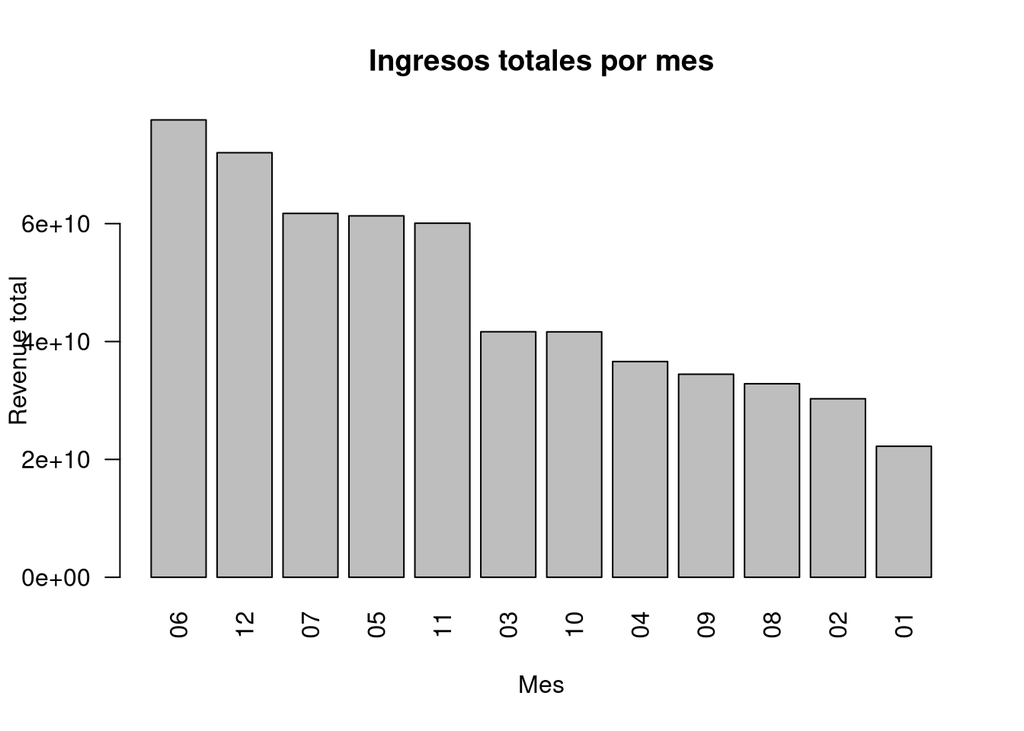

**Análisis:** La gráfica muestra qué meses concentran más ingresos acumulados según la fecha de estreno. Esto puede reflejar estacionalidad (por ejemplo, temporadas de vacaciones o estrenos grandes). Como es una suma total, los meses con más películas también pueden subir en el ranking. Si se quiere aislar el efecto del mes, conviene comparar revenue promedio por mes.

## 4.16 Revenue promedio según presencia de página web y video

| has_homepage | has_video | revenue_promedio | revenue_millones |
| --- | --- | --- | --- |
| Con Web | Sin Video | 175326526 | 175.33 |
| Sin Web | Sin Video | 77420233 | 77.42 |
| Sin Web | Con Video | 25422088 | 25.42 |
| Con Web | Con Video | 3103950 | 3.10 |

**Análisis:** La tabla compara el revenue promedio según si la película tiene `homePage` y/o `video` marcado. Esto sirve como aproximación al “impacto de marketing”, aunque no prueba causalidad. Es posible que producciones grandes tengan más recursos para web/video y también más ingresos por otros motivos. Aun así, ayuda a ver si existe una señal consistente en el promedio.

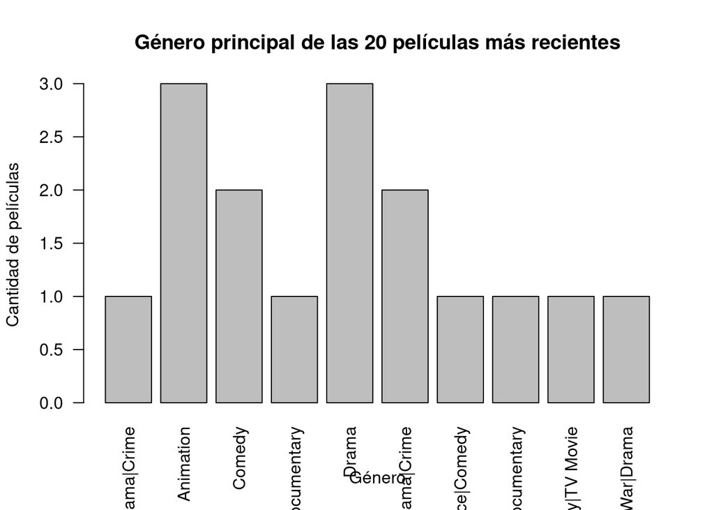

## 6.1 Género principal de las películas más largas

```
##                                                   title runtime  main_genre
## 1 How Ponyo was Born ~Hayao Miyazaki's Thought Process~     750 Documentary
```

**Análisis:** Se identifica la(s) película(s) con mayor duración y su género principal. Esto ayuda a ver si las películas más largas se concentran en un tipo de género específico o si es algo disperso. Si hay empates en duración máxima, se muestran varias filas. Conviene revisar también si hay valores extremos por errores de captura.

## 9 Relación entre composición del elenco y popularidad/ingresos

| relacion | correlacion |
| --- | --- |
| Mujeres vs Popularidad | 0.0101 |
| Hombres vs Popularidad | 0.0215 |
| Mujeres vs Ingresos (log) | -0.0405 |
| Hombres vs Ingresos (log) | -0.0663 |

| modelo | term | estimate | std.error | statistic | p.value |
| --- | --- | --- | --- | --- | --- |
| Popularidad | (Intercept) | 12.0344 | 1.3528 | 8.8960 | 0.0000 |
| Popularidad | castWomenAmount | 3.5355 | 0.1979 | 17.8652 | 0.0000 |
| Popularidad | castMenAmount | 0.0000 | 0.0000 | 3.1055 | 0.0019 |
| Ingresos (log) | (Intercept) | 1.7091 | 0.0552 | 30.9570 | 0.0000 |
| Ingresos (log) | castWomenAmount | 0.7561 | 0.0081 | 93.6164 | 0.0000 |
| Ingresos (log) | castMenAmount | 0.0000 | 0.0000 | -10.9085 | 0.0000 |

| modelo | r.squared | adj.r.squared | AIC | BIC |
| --- | --- | --- | --- | --- |
| Popularidad | 0.0164 | 0.0163 | 254987.6 | 255019.2 |
| Ingresos (log) | 0.3108 | 0.3107 | 128820.8 | 128852.3 |

**Análisis:** Las correlaciones dan una señal rápida de asociación lineal entre el tamaño del elenco por género y la popularidad/ingresos (en log). El modelo lineal permite ver el efecto conjunto de ambas variables controlándose entre sí. Si los coeficientes no son significativos, sugiere que estas variables explican poco la variación, al menos de forma lineal. En la práctica, también podrían existir variables de confusión como presupuesto, marketing o distribución.

## 12 Ingreso promedio por mes de lanzamiento (gráfico)

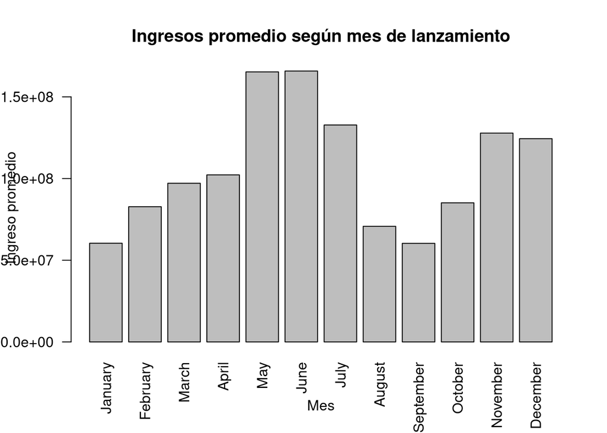

**Análisis:** A diferencia de la suma total, este gráfico compara el revenue promedio por mes, lo que reduce el sesgo de “meses con más películas”. Si ciertos meses destacan consistentemente, puede indicar ventanas de estreno más favorables. Aun así, el promedio puede ser sensible a outliers (blockbusters muy grandes). Para robustez se puede usar la mediana o un gráfico de cajas por mes.

## 15 Popularidad del elenco vs éxito de taquilla (correlación, regresión y gráfico)

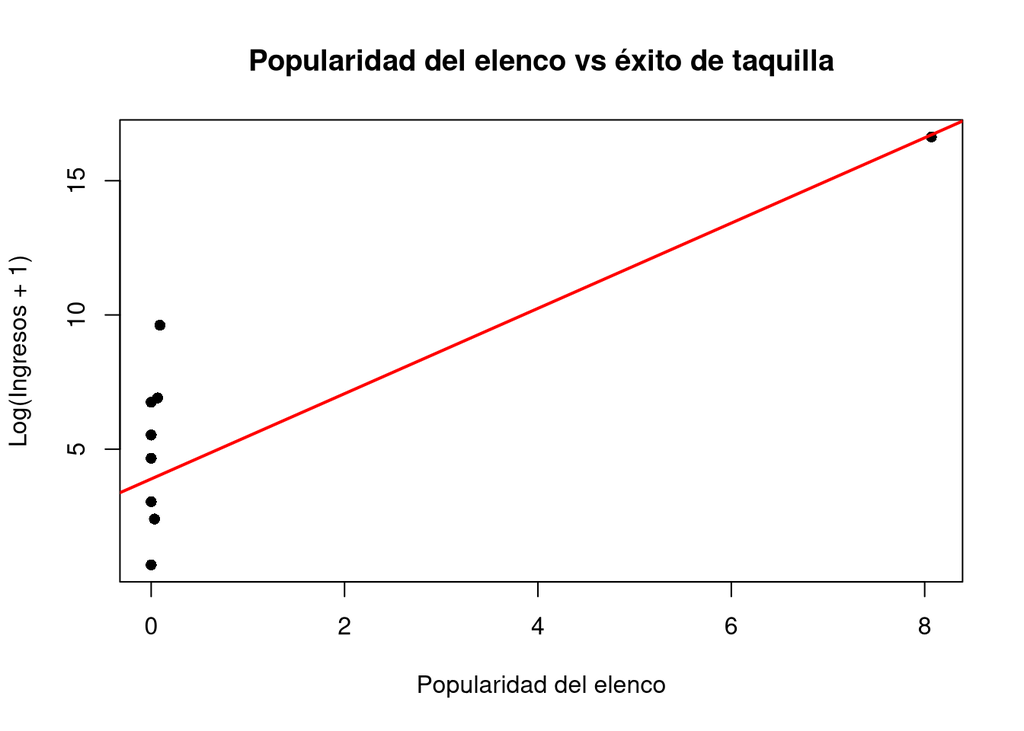

```
## Correlación entre popularidad del elenco e ingresos (log):
```

```
## 0.7978584
```

```
## Modelo lineal:
```

```
##
## Call:
## lm(formula = log(revenue + 1) ~ actorsPopularity, data = movies_clean_cast)
##
## Residuals:
##    Min     1Q Median     3Q    Max
## -3.197 -1.546 -0.846  1.635  5.581
##
## Coefficients:
##                  Estimate Std. Error t value Pr(>|t|)
## (Intercept)        3.8905     0.8100   4.803 0.000551 ***
## actorsPopularity   1.5886     0.3619   4.390 0.001082 **
## ---
## Signif. codes:  0 '***' 0.001 '**' 0.01 '*' 0.05 '.' 0.1 ' ' 1
##
## Residual standard error: 2.8 on 11 degrees of freedom
## Multiple R-squared:  0.6366, Adjusted R-squared:  0.6035
## F-statistic: 19.27 on 1 and 11 DF,  p-value: 0.001082
```

**Análisis:** La nube de puntos muestra si existe un patrón creciente entre la popularidad del elenco y los ingresos (en escala log). La correlación resume esa asociación y la regresión estima una tendencia promedio. Si la dispersión es alta, significa que la popularidad del elenco no explica por sí sola el éxito de taquilla. En ese caso, conviene agregar variables como presupuesto, género o fecha de estreno en un modelo multivariado.

## Preguntas extra 1 Clustering financiero (budget vs revenue)

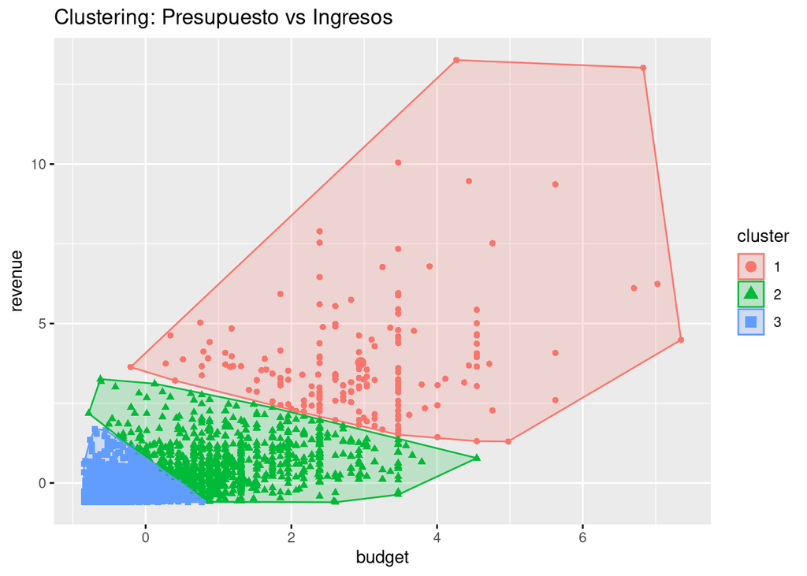

```
##   cluster    budget   revenue
## 1       1 176190145 899005440
## 2       2  94289095 258207095
## 3       3  20084865  55739764
```

**Análisis:** El clustering agrupa películas según similitud en presupuesto e ingresos, creando “categorías financieras” sin etiquetas predefinidas. Las medias por cluster ayudan a interpretar cada grupo (por ejemplo, alto presupuesto/alto ingreso vs. bajo presupuesto). Como se usan datos escalados, el algoritmo no se sesga por la magnitud de una variable frente a otra. El número de clusters (3) es una decisión que puede ajustarse con métodos como codo o silhouette.

## Preguntas extra 2 Culto vs virales (voteAvg vs popularity)

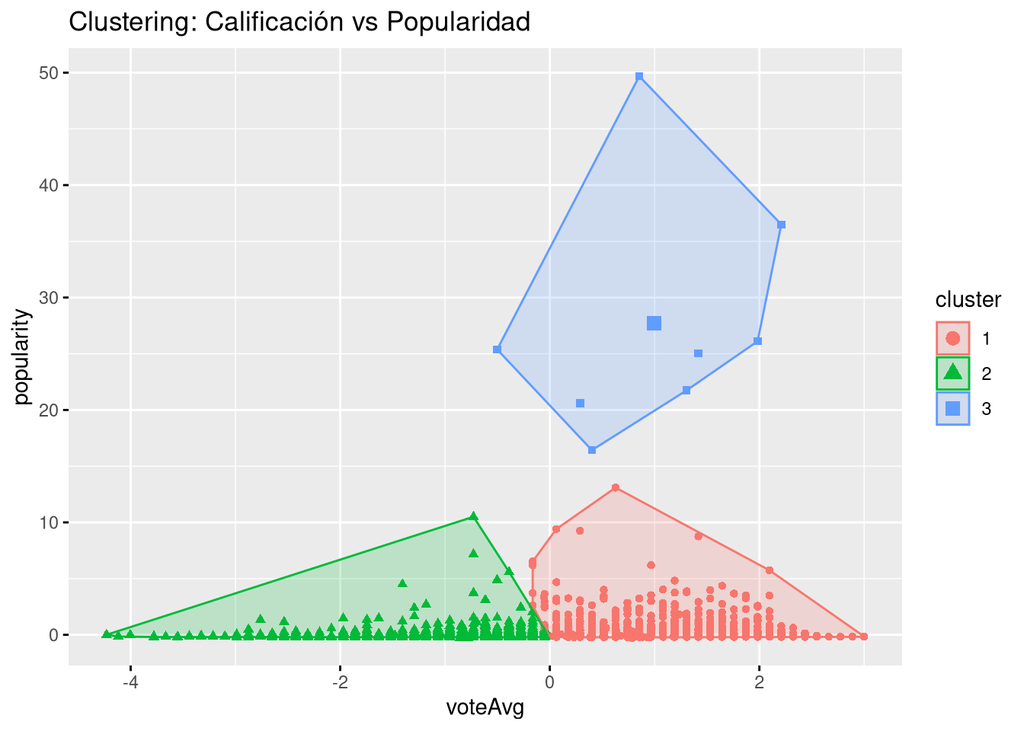

```
##   cluster  voteAvg popularity
## 1       1 7.236344   57.23974
## 2       2 5.819501   36.21563
## 3       3 7.425000 6416.89387
```

**Análisis:** Este clustering busca separar patrones como “alta calificación/baja popularidad” frente a “alta popularidad/calificación variable”. Es una forma rápida de segmentar el comportamiento sin reglas manuales. El filtro de `voteCount > 50` mejora la estabilidad de `voteAvg`. Para nombrar los clusters, se revisan las medias y se comparan con la nube de puntos.

## Preguntas extra 3 Top 10 por ROI

| title | budget | revenue | ROI |
| --- | --- | --- | --- |
| Alice in Wonderland | 3000000 | 572000000 | 189.66667 |
| Snow White and the Seven Dwarfs | 1488423 | 184925486 | 123.24256 |
| Gone with the Wind | 4000000 | 402352579 | 99.58814 |
| The Rocky Horror Picture Show | 1200000 | 112892319 | 93.07693 |
| Cinderella | 2900000 | 263591415 | 89.89359 |
| Saw | 1200000 | 103911669 | 85.59306 |
| E.T. the Extra-Terrestrial | 10500000 | 792965500 | 74.52052 |
| My Big Fat Greek Wedding | 5000000 | 368744044 | 72.74881 |
| Star Wars | 11000000 | 775398007 | 69.49073 |
| Saturday Night Fever | 3500000 | 237113184 | 66.74662 |

**Análisis:** El ROI mide rentabilidad relativa, evitando la trampa de fijarse solo en revenue absoluto. Una película con ingresos modestos puede ser muy rentable si su presupuesto fue bajo. El filtro de presupuesto > 1M reduce casos extremos por “micropresupuestos” que inflan el ROI artificialmente. Este top es útil para estudiar estrategias de producción eficientes.

## Preguntas extra 4 Coproducción vs revenue (boxplot)

```
##   es_coproduccion   revenue
## 1              No 106977342
## 2              Si 103856831
```

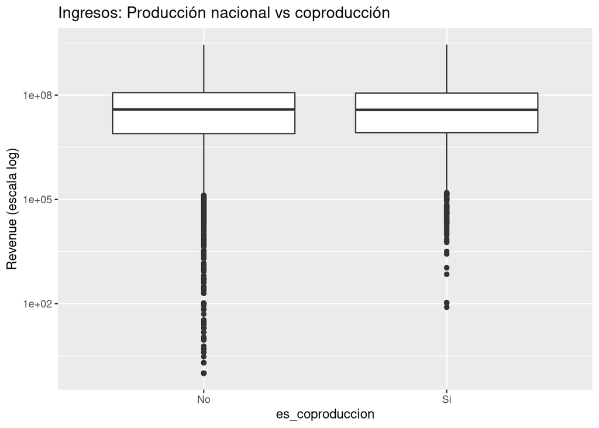

**Análisis:** Aquí se compara si las coproducciones tienden a generar más ingresos promedio que las producciones de un solo país. El boxplot permite ver tanto la mediana como la dispersión, usando escala log para manejar valores muy grandes. Si la distribución de “Sí” está por encima de “No”, sugiere una ventaja en ingresos, aunque no necesariamente causal. Conviene revisar tamaño de muestra por grupo para no sobreinterpretar.

## Preguntas extra 5 Calificación promedio por rango de duración (gráfico)

```
##   rango_duracion  voteAvg
## 1        <90 min 2.701265
## 2     90-120 min 5.790743
## 3    120-150 min 6.170026
## 4       >150 min 5.724146
```

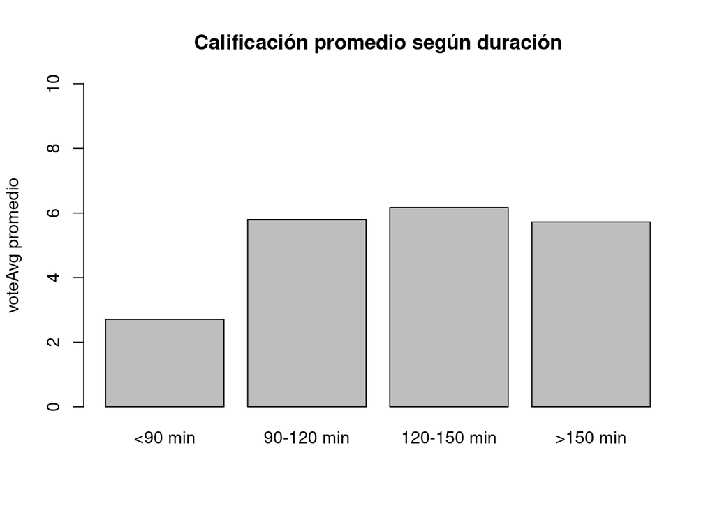

**Análisis:** Este análisis agrupa las películas por duración y calcula su calificación promedio. Sirve para ver si existe una “zona” donde, en promedio, las películas reciben mejores valoraciones. Como se usa promedio, grupos con pocas películas pueden ser inestables. Si se detectan diferencias claras, se puede profundizar con boxplots o pruebas estadísticas.

## Preguntas extra 6 Clustering calidad (budget vs voteAvg)

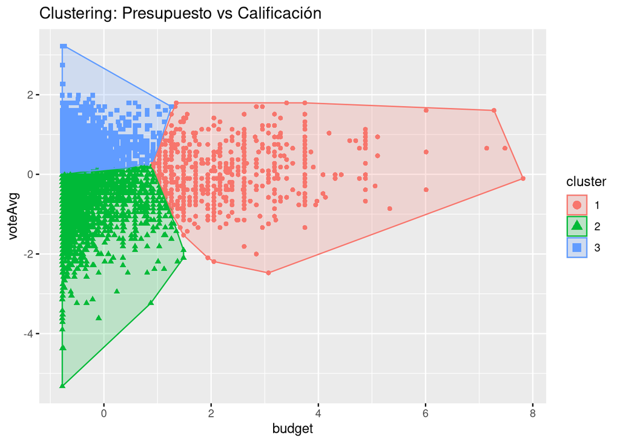

```
##   cluster    budget  voteAvg
## 1       1 136429551 6.705811
## 2       2  25081252 5.873428
## 3       3  16939485 7.510606
```

**Análisis:** Este clustering agrupa películas por presupuesto y calificación promedio, explorando si “el dinero compra buenas críticas”. Las medias por cluster permiten interpretar si hay un grupo de alto presupuesto/alta calificación o si no existe esa relación. Como se usa k-means, se asume una estructura de clusters relativamente “redondeada” en el espacio escalado. Si los clusters se solapan mucho, es señal de que la relación es débil o no lineal.